# Homework 1 - Exploratory Data Analysis

Author

Nate Truettner

## 1

```r
library(dplyr)
library(lubridate)
pm_2005 <- read.csv('pm_25_mich_2005.csv')
pm_2025 <- read.csv('pm_25_mich_2025.csv')
```

### 2005 data

```r
dim(pm_2005)
```

```
[1] 5280   22
```

```r
head(pm_2005)
```

```
        Date Source   Site.ID POC Daily.Mean.PM2.5.Concentration    Units
1 01/01/2005    AQS 260050003   1                            9.3 ug/m3 LC
2 01/02/2005    AQS 260050003   1                            7.0 ug/m3 LC
3 01/03/2005    AQS 260050003   1                           15.7 ug/m3 LC
4 01/04/2005    AQS 260050003   1                           13.4 ug/m3 LC
5 01/05/2005    AQS 260050003   1                            5.3 ug/m3 LC
6 01/06/2005    AQS 260050003   1                            4.0 ug/m3 LC
  Daily.AQI.Value           Local.Site.Name Daily.Obs.Count Percent.Complete
1              51 1016 W. 32nd St (Holland)               1              100
2              39 1016 W. 32nd St (Holland)               1              100
3              63 1016 W. 32nd St (Holland)               1              100
4              59 1016 W. 32nd St (Holland)               1              100
5              29 1016 W. 32nd St (Holland)               1              100
6              22 1016 W. 32nd St (Holland)               1              100
  AQS.Parameter.Code AQS.Parameter.Description Method.Code
```

[output cut: 27 more lines]

```r
tail(pm_2005)
```

```
           Date Source   Site.ID POC Daily.Mean.PM2.5.Concentration    Units
5275 09/01/2005    AQS 261639901   1                           12.8 ug/m3 LC
5276 09/07/2005    AQS 261639901   1                           30.4 ug/m3 LC
5277 09/13/2005    AQS 261639901   1                           46.5 ug/m3 LC
5278 09/25/2005    AQS 261639901   1                           24.4 ug/m3 LC
5279 10/01/2005    AQS 261639901   1                           24.0 ug/m3 LC
5280 10/07/2005    AQS 261639901   1                            2.9 ug/m3 LC
     Daily.AQI.Value Local.Site.Name Daily.Obs.Count Percent.Complete
5275              58                               1              100
5276              91                               1              100
5277             128                               1              100
5278              80                               1              100
5279              79                               1              100
5280              16                               1              100
     AQS.Parameter.Code              AQS.Parameter.Description Method.Code
```

[output cut: 27 more lines]

```r
str(pm_2005)
```

```
'data.frame':   5280 obs. of  22 variables:
 $ Date                          : chr  "01/01/2005" "01/02/2005" "01/03/2005" "01/04/2005" ...
 $ Source                        : chr  "AQS" "AQS" "AQS" "AQS" ...
 $ Site.ID                       : int  260050003 260050003 260050003 260050003 260050003 260050003 260050003 260050003 260050003 260050003 ...
 $ POC                           : int  1 1 1 1 1 1 1 1 1 1 ...
 $ Daily.Mean.PM2.5.Concentration: num  9.3 7 15.7 13.4 5.3 4 12.6 29 15.5 13.2 ...
 $ Units                         : chr  "ug/m3 LC" "ug/m3 LC" "ug/m3 LC" "ug/m3 LC" ...
 $ Daily.AQI.Value               : int  51 39 63 59 29 22 58 88 63 59 ...
 $ Local.Site.Name               : chr  "1016 W. 32nd St (Holland)" "1016 W. 32nd St (Holland)" "1016 W. 32nd St (Holland)" "1016 W. 32nd St (Holland)" ...
 $ Daily.Obs.Count               : int  1 1 1 1 1 1 1 1 1 1 ...
 $ Percent.Complete              : num  100 100 100 100 100 100 100 100 100 100 ...
 $ AQS.Parameter.Code            : int  88101 88101 88101 88101 88101 88101 88101 88101 88101 88101 ...
 $ AQS.Parameter.Description     : chr  "PM2.5 - Local Conditions" "PM2.5 - Local Conditions" "PM2.5 - Local Conditions" "PM2.5 - Local Conditions" ...
 $ Method.Code                   : int  118 118 118 118 118 118 118 118 118 118 ...
 $ Method.Description            : chr  "R & P Model 2025 PM2.5 Sequential w/WINS" "R & P Model 2025 PM2.5 Sequential w/WINS" "R & P Model 2025 PM2.5 Sequential w/WINS" "R & P Model 2025 PM2.5 Sequential w/WINS" ...
 $ CBSA.Code                     : int  26090 26090 26090 26090 26090 26090 26090 26090 26090 26090 ...
 $ CBSA.Name                     : chr  "Holland, MI" "Holland, MI" "Holland, MI" "Holland, MI" ...
 $ State.FIPS.Code               : int  26 26 26 26 26 26 26 26 26 26 ...
 $ State                         : chr  "Michigan" "Michigan" "Michigan" "Michigan" ...
 $ County.FIPS.Code              : int  5 5 5 5 5 5 5 5 5 5 ...
 $ County                        : chr  "Allegan" "Allegan" "Allegan" "Allegan" ...
 $ Site.Latitude                 : num  42.8 42.8 42.8 42.8 42.8 ...
 $ Site.Longitude                : num  -86.2 -86.2 -86.2 -86.2 -86.2 ...
```

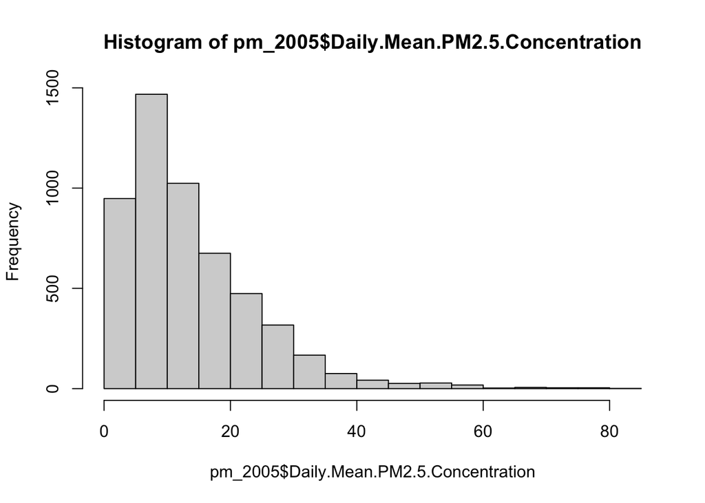

```r
hist(pm_2005$Daily.Mean.PM2.5.Concentration)
```

### 2025 data

```r
dim(pm_2025)
```

```
[1] 9934   22
```

```r
head(pm_2025)
```

```
        Date Source   Site.ID POC Daily.Mean.PM2.5.Concentration    Units
1 01/01/2025    AQS 260050003   1                            3.7 ug/m3 LC
2 01/02/2025    AQS 260050003   1                            4.5 ug/m3 LC
3 01/03/2025    AQS 260050003   1                            3.8 ug/m3 LC
4 01/04/2025    AQS 260050003   1                            3.3 ug/m3 LC
5 01/05/2025    AQS 260050003   1                            4.6 ug/m3 LC
6 01/06/2025    AQS 260050003   1                            3.3 ug/m3 LC
  Daily.AQI.Value           Local.Site.Name Daily.Obs.Count Percent.Complete
1              21 1016 W. 32nd St (Holland)               1              100
2              25 1016 W. 32nd St (Holland)               1              100
3              21 1016 W. 32nd St (Holland)               1              100
4              18 1016 W. 32nd St (Holland)               1              100
5              26 1016 W. 32nd St (Holland)               1              100
6              18 1016 W. 32nd St (Holland)               1              100
  AQS.Parameter.Code AQS.Parameter.Description Method.Code
```

[output cut: 20 more lines]

```r
tail(pm_2025)
```

```
           Date Source   Site.ID POC Daily.Mean.PM2.5.Concentration    Units
9929 12/26/2025 AirNow 261630100   1                            5.2 ug/m3 LC
9930 12/27/2025 AirNow 261630100   1                            5.4 ug/m3 LC
9931 12/28/2025 AirNow 261630100   1                           10.7 ug/m3 LC
9932 12/29/2025 AirNow 261630100   1                            2.4 ug/m3 LC
9933 12/30/2025 AirNow 261630100   1                            3.4 ug/m3 LC
9934 12/31/2025 AirNow 261630100   1                            6.7 ug/m3 LC
     Daily.AQI.Value      Local.Site.Name Daily.Obs.Count Percent.Complete
9929              29 Military Park (GHIB)               1              100
9930              30 Military Park (GHIB)               1              100
9931              54 Military Park (GHIB)               1              100
9932              13 Military Park (GHIB)               1              100
9933              19 Military Park (GHIB)               1              100
9934              37 Military Park (GHIB)               1              100
     AQS.Parameter.Code AQS.Parameter.Description Method.Code
```

[output cut: 20 more lines]

```r
str(pm_2025)
```

```
'data.frame':   9934 obs. of  22 variables:
 $ Date                          : chr  "01/01/2025" "01/02/2025" "01/03/2025" "01/04/2025" ...
 $ Source                        : chr  "AQS" "AQS" "AQS" "AQS" ...
 $ Site.ID                       : int  260050003 260050003 260050003 260050003 260050003 260050003 260050003 260050003 260050003 260050003 ...
 $ POC                           : int  1 1 1 1 1 1 1 1 1 1 ...
 $ Daily.Mean.PM2.5.Concentration: num  3.7 4.5 3.8 3.3 4.6 3.3 3 2.8 7.7 17.7 ...
 $ Units                         : chr  "ug/m3 LC" "ug/m3 LC" "ug/m3 LC" "ug/m3 LC" ...
 $ Daily.AQI.Value               : int  21 25 21 18 26 18 17 16 43 67 ...
 $ Local.Site.Name               : chr  "1016 W. 32nd St (Holland)" "1016 W. 32nd St (Holland)" "1016 W. 32nd St (Holland)" "1016 W. 32nd St (Holland)" ...
 $ Daily.Obs.Count               : int  1 1 1 1 1 1 1 1 1 1 ...
 $ Percent.Complete              : num  100 100 100 100 100 100 100 100 100 100 ...
 $ AQS.Parameter.Code            : int  88101 88101 88101 88101 88101 88101 88101 88101 88101 88101 ...
 $ AQS.Parameter.Description     : chr  "PM2.5 - Local Conditions" "PM2.5 - Local Conditions" "PM2.5 - Local Conditions" "PM2.5 - Local Conditions" ...
 $ Method.Code                   : int  170 170 170 170 170 170 170 170 170 170 ...
 $ Method.Description            : chr  "Met One BAM-1020 Mass Monitor w/VSCC" "Met One BAM-1020 Mass Monitor w/VSCC" "Met One BAM-1020 Mass Monitor w/VSCC" "Met One BAM-1020 Mass Monitor w/VSCC" ...
 $ CBSA.Code                     : int  26090 26090 26090 26090 26090 26090 26090 26090 26090 26090 ...
 $ CBSA.Name                     : chr  "Holland, MI" "Holland, MI" "Holland, MI" "Holland, MI" ...
 $ State.FIPS.Code               : int  26 26 26 26 26 26 26 26 26 26 ...
 $ State                         : chr  "Michigan" "Michigan" "Michigan" "Michigan" ...
 $ County.FIPS.Code              : int  5 5 5 5 5 5 5 5 5 5 ...
 $ County                        : chr  "Allegan" "Allegan" "Allegan" "Allegan" ...
 $ Site.Latitude                 : num  42.8 42.8 42.8 42.8 42.8 ...
 $ Site.Longitude                : num  -86.2 -86.2 -86.2 -86.2 -86.2 ...
```

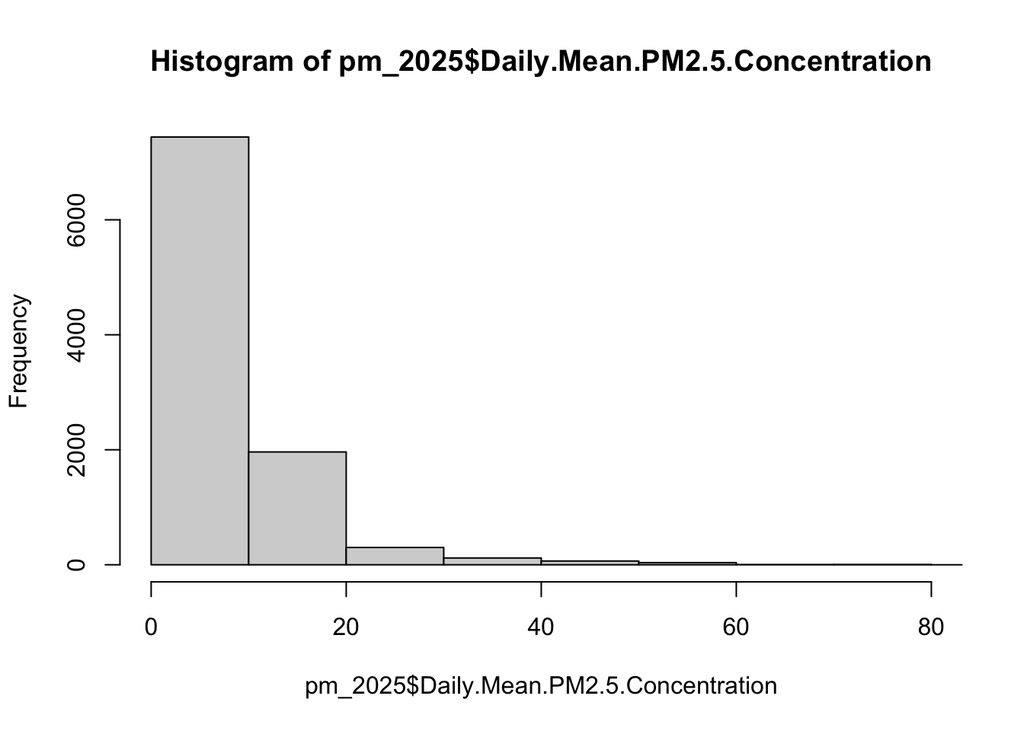

```r
hist(pm_2025$Daily.Mean.PM2.5.Concentration, xlim=c(0,80))
```

The 2005 dataset has 5280 rows and 22 columns while the 2025 dataset has 9934 rows and 22 columns. The datasets appear to share the same columns, which include integer, numeric, and character type variables. Assessing the distribution of PM2.5 in 2005 and 2025, we notice that the 2005 dataset has a more prominent tail, meaning that there were more recordings of high PM2.5 in 2005 than 2025. Additionally, the mean PM2.5 value seems to be lower in 2025 as the first bin (assume low PM2.5) is a very tall peak. From this, we can reasonably conclude that PM2.5 has generally decreased since 2005 in the state of Michigan.

## 2

```r
full_pm <- rbind(pm_2005, pm_2025)
full_pm <- full_pm %>%
  rename(pm2.5 = Daily.Mean.PM2.5.Concentration,
         AQI = Daily.AQI.Value)
full_pm <- full_pm %>%
  mutate(Date = mdy(Date))
full_pm <- full_pm %>%
  mutate(year = year(Date))
str(full_pm)
```

```
'data.frame':   15214 obs. of  23 variables:
 $ Date                     : Date, format: "2005-01-01" "2005-01-02" ...
 $ Source                   : chr  "AQS" "AQS" "AQS" "AQS" ...
 $ Site.ID                  : int  260050003 260050003 260050003 260050003 260050003 260050003 260050003 260050003 260050003 260050003 ...
 $ POC                      : int  1 1 1 1 1 1 1 1 1 1 ...
 $ pm2.5                    : num  9.3 7 15.7 13.4 5.3 4 12.6 29 15.5 13.2 ...
 $ Units                    : chr  "ug/m3 LC" "ug/m3 LC" "ug/m3 LC" "ug/m3 LC" ...
 $ AQI                      : int  51 39 63 59 29 22 58 88 63 59 ...
 $ Local.Site.Name          : chr  "1016 W. 32nd St (Holland)" "1016 W. 32nd St (Holland)" "1016 W. 32nd St (Holland)" "1016 W. 32nd St (Holland)" ...
 $ Daily.Obs.Count          : int  1 1 1 1 1 1 1 1 1 1 ...
 $ Percent.Complete         : num  100 100 100 100 100 100 100 100 100 100 ...
 $ AQS.Parameter.Code       : int  88101 88101 88101 88101 88101 88101 88101 88101 88101 88101 ...
 $ AQS.Parameter.Description: chr  "PM2.5 - Local Conditions" "PM2.5 - Local Conditions" "PM2.5 - Local Conditions" "PM2.5 - Local Conditions" ...
 $ Method.Code              : int  118 118 118 118 118 118 118 118 118 118 ...
 $ Method.Description       : chr  "R & P Model 2025 PM2.5 Sequential w/WINS" "R & P Model 2025 PM2.5 Sequential w/WINS" "R & P Model 2025 PM2.5 Sequential w/WINS" "R & P Model 2025 PM2.5 Sequential w/WINS" ...
 $ CBSA.Code                : int  26090 26090 26090 26090 26090 26090 26090 26090 26090 26090 ...
 $ CBSA.Name                : chr  "Holland, MI" "Holland, MI" "Holland, MI" "Holland, MI" ...
 $ State.FIPS.Code          : int  26 26 26 26 26 26 26 26 26 26 ...
 $ State                    : chr  "Michigan" "Michigan" "Michigan" "Michigan" ...
 $ County.FIPS.Code         : int  5 5 5 5 5 5 5 5 5 5 ...
 $ County                   : chr  "Allegan" "Allegan" "Allegan" "Allegan" ...
 $ Site.Latitude            : num  42.8 42.8 42.8 42.8 42.8 ...
 $ Site.Longitude           : num  -86.2 -86.2 -86.2 -86.2 -86.2 ...
 $ year                     : num  2005 2005 2005 2005 2005 ...
```

## 3

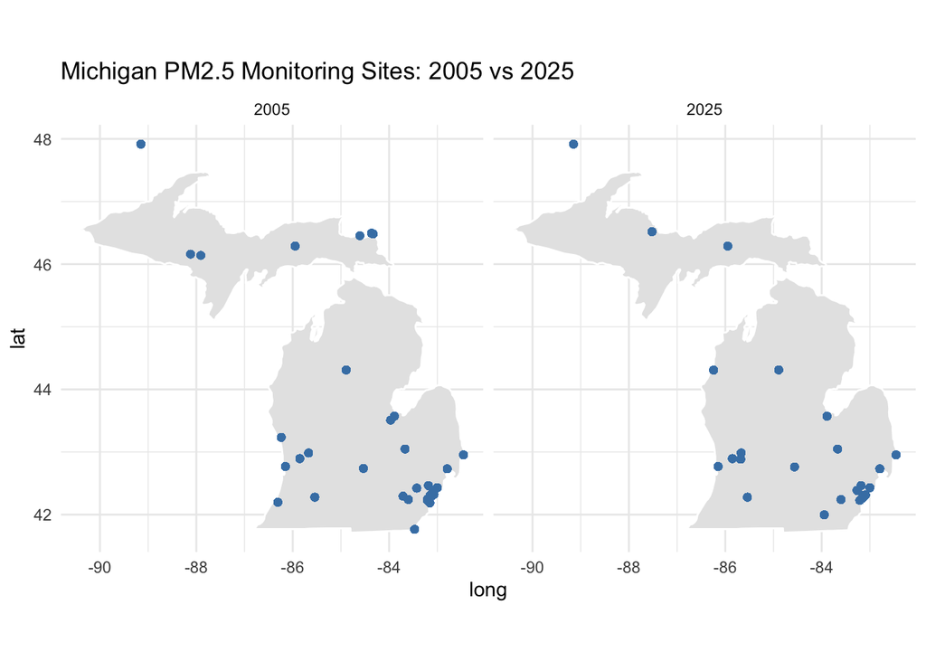

```r
library(leaflet)
library(ggplot2)
library(maps)
us_map <- map_data("state")
mi_map <- map_data("state") %>%
  filter(region == "michigan")
ggplot() +
  geom_polygon(data = mi_map,
               aes(x = long, y = lat, group = group),
               fill = "gray90", color = "white") +
  geom_point(data = full_pm,
             aes(x = Site.Longitude, y = Site.Latitude),
             color = "steelblue",
             alpha = 0.7) +
  coord_fixed(1.3) +
  facet_wrap(~year) +
  labs(title = "Michigan PM2.5 Monitoring Sites: 2005 vs 2025") +
  theme_minimal()
```

The 2005 distribution shows that the monitoring sites are mostly concentrated in the southern half of Michigan, with many in the southeast. In 2025, we notice that a few of the sites in the upper peninsula are no longer active, but there are a comparable number in the mainland. Generally, there appear to be fewer monitoring sites in 2025 compared to 2005.

## 4

```r
summary(full_pm$pm2.5)
```

```
   Min. 1st Qu.  Median    Mean 3rd Qu.    Max.
    0.0     4.5     7.4    10.2    12.5   116.0
```

```r
table(full_pm$Method.Code)
```

```
 118  145  170  636  638  707  781  810
4358  324 1741 3941 1336  320   44  607
```

The two most common method codes are 118 and 636. Code 118 corresponds to gravimetric analysis, which is done intermittently while code 636 corresponds to a continuous air monitor performing broadband spectroscopy.

```r
table(pm_2005$Method.Code)
```

```
 118  707  781  810
4358  271   44  607
```

```r
table(pm_2025$Method.Code)
```

```
 145  170  636  638  707
 324 1741 3941 1336   49
```

Looking at data from each year, it is evident that in 2005, code 118 was prevalent while in 2025 636 is most common. This represents a shift from manual lab analysis to automated data collection. This is notable as differences over time may not be true differences in PM2.5, but simply reflecting the adjustment from one collection technique to another. There are no missing values for PM2.5 in the dataset.

## 5

### State-level

```r
state_summary <- full_pm %>%
  group_by(year) %>%
  summarise(
    mean_pm25 = mean(pm2.5),
    median_pm25 = median(pm2.5),
    max_pm25 = max(pm2.5),
    min_pm25 = min(pm2.5)
  )
state_summary
```

```
# A tibble: 2 × 5
   year mean_pm25 median_pm25 max_pm25 min_pm25
  <dbl>     <dbl>       <dbl>    <dbl>    <dbl>
1  2005     13.8         11       81.6        0
2  2025      8.30         6.3    116          0
```

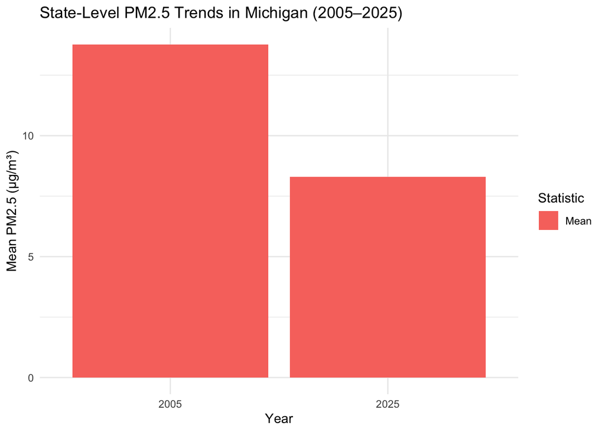

```r
ggplot(state_summary, aes(x = factor(year), y = mean_pm25, fill = "Mean")) +
  geom_bar(stat = "identity") +
  labs(
    title = "State-Level PM2.5 Trends in Michigan (2005–2025)",
    x = "Year",
    y = "Mean PM2.5 (µg/m³)",
    fill = "Statistic"
  ) +
  theme_minimal()
```

At the state level, PM2.5 appears to have decreased in the past 20 years. The mean PM2.5 value in 2005 was 13.77 ug/m3 while in 2025 it was 8.30. The range of observations is greater in 2025 than 2005, suggesting possible larger variance in the automated collection system.

### County-level

```r
county_summary <- full_pm %>%
  group_by(County, year) %>%
  summarise(mean_pm25 = mean(pm2.5),
            median_pm25 = median(pm2.5),
            latitude = mean(Site.Latitude),
            longitude = mean(Site.Longitude))
county_summary
```

```
# A tibble: 40 × 6
# Groups:   County [25]
   County     year mean_pm25 median_pm25 latitude longitude
   <chr>     <dbl>     <dbl>       <dbl>    <dbl>     <dbl>
 1 Allegan    2005     12.7        10.4      42.8     -86.2
 2 Allegan    2025      8.95        7.2      42.8     -86.2
 3 Bay        2005     12.4         9.7      43.6     -83.9
 4 Bay        2025      8.54        6.8      43.6     -83.9
 5 Berrien    2005     13.1        10.8      42.2     -86.3
 6 Chippewa   2005      8.25        6        46.5     -84.4
 7 Dickinson  2005      7.32        6.9      46.1     -87.9
 8 Genesee    2005     12.9        10.7      43.0     -83.7
 9 Genesee    2025      6.54        5.25     43.0     -83.7
10 Ingham     2005     13.5        11.2      42.7     -84.5
# ℹ 30 more rows
```

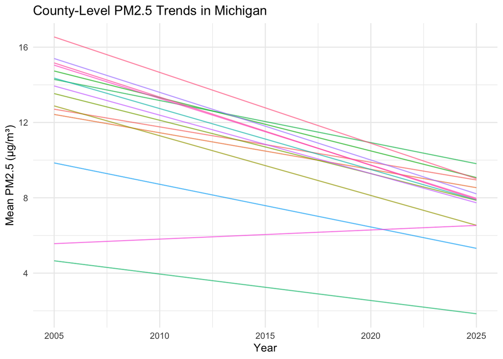

```r
ggplot(county_summary, aes(x = year, y = mean_pm25, color = County)) +
  geom_line(alpha = 0.7) +
  labs(
    title = "County-Level PM2.5 Trends in Michigan",
    x = "Year",
    y = "Mean PM2.5 (µg/m³)"
  ) +
  theme_minimal() +
  theme(legend.position = "none")
```

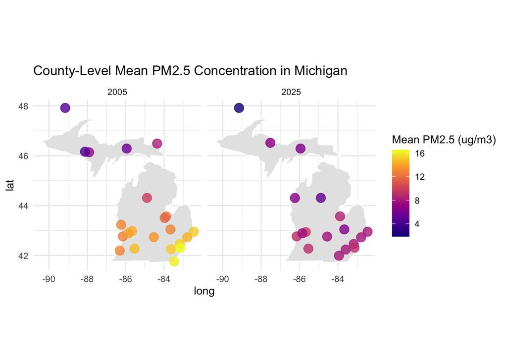

```r
ggplot() +
  geom_polygon(data = mi_map, aes(x = long, y = lat, group = group),
               fill = "gray90", color = "white") +
  geom_point(data = county_summary,
             aes(x = longitude, y = latitude, color = mean_pm25),
             size = 4, alpha = 0.8) +
  scale_color_viridis_c(option = "C") +
  facet_wrap(~year) +
  coord_fixed(1.3) +
  labs(title = "County-Level Mean PM2.5 Concentration in Michigan",
       color = "Mean PM2.5 (ug/m3)") +
  theme_minimal()
```

At the county level, I first made a line/spaghetti plot to see if mean PM2.5 has generally decreased in every county. In almost every county, PM2.5 concentration decreased in 2025 from 2005. The only exception is Schoolcraft County, which saw about a 1 ug/m3 increase in PM2.5. Examining the spatial plot with a color gradient describing PM2.5 concentration, we notice that generally, PM2.5 has gone down over time, as the hue turns from yellow to purple.

### City-level

```r
wayne <- full_pm %>%
  filter(County == "Wayne")
table(wayne$Local.Site.Name)
```

```
                                                       44
                                  92 FEET FROM WHE STREET
                                                      113
                                               Allen Park
                                                      969
                                              DET-LINWOOD
                                                      338
                                        Detroit-Southwest
                                                      575
          DP4th - Detroit Police 4th Precinct (near GHIB)
                                                      363
                                              East 7 Mile
                                                      481
                                          Eliza Howell-NR
                                                      357
                                            FIA/Lafayette
                                                       35
                                     Military Park (GHIB)
                                                      363
                                          Newberry School
                                                       75
                            NMH48217 NEW MT HERMAN CHURCH
                                                      365
                PROPERTY OWNED BY DEARBORN PUBLIC SCHOOLS
                                                      635
                                      SCHOOLCRAFT COLLEGE
                                                      114
TRINITY ST MARKS - Gordy Howe International Bridge (GHIB)
                                                      365
```

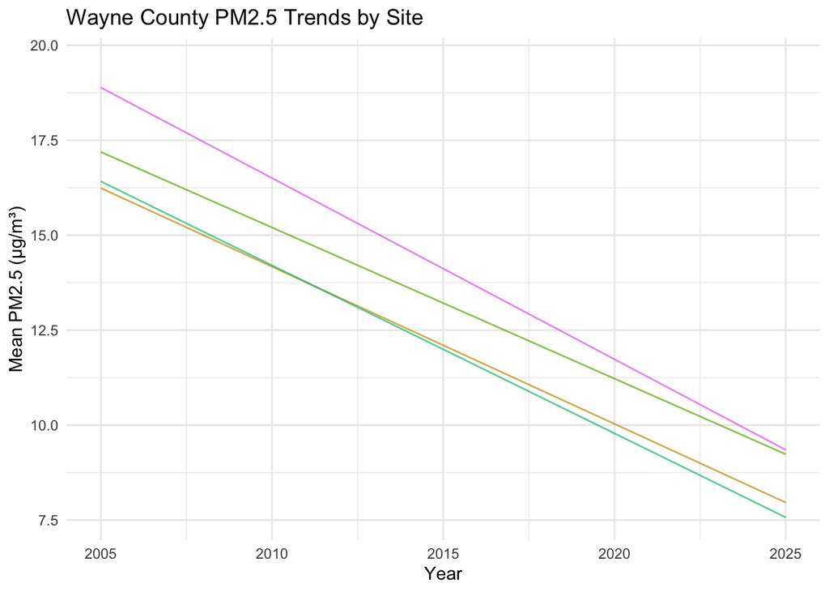

```r
wayne_summary <- wayne %>%
  group_by(Local.Site.Name, year) %>%
  summarise(
    mean_pm25 = mean(pm2.5),
    median_pm25 = median(pm2.5),
    latitude = mean(Site.Latitude),
    longitude = mean(Site.Longitude)
  )
ggplot(wayne_summary, aes(x = year, y = mean_pm25, color = Local.Site.Name)) +
  geom_line(alpha = 0.7) +
  labs(
    title = "Wayne County PM2.5 Trends by Site",
    x = "Year",
    y = "Mean PM2.5 (µg/m³)"
  ) +
  theme_minimal() +
  theme(legend.position = "none")
```

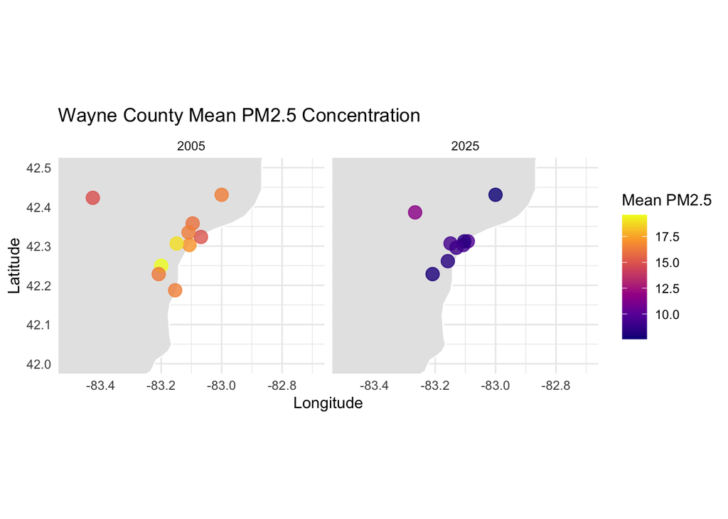

```r
ggplot() +
  geom_polygon(data = mi_map, aes(x = long, y = lat, group = group),
               fill = "gray90", color = "white") +
  geom_point(data = wayne_summary,
             aes(x = longitude, y = latitude, color = mean_pm25),
             size = 4, alpha = 0.8) +
  coord_fixed(1.3, xlim = c(-83.5, -82.7), ylim = c(42.0, 42.5)) +
  scale_color_viridis_c(option = "C") +
  facet_wrap(~year) +
  labs(title = "Wayne County Mean PM2.5 Concentration",
       x = "Longitude",
       y = "Latitude",
       color = "Mean PM2.5") +
  theme_minimal()
```